# 4_DMW2021-Lab 4

### 5.2.3 Defenders

### 5.2.3.1 Principal Component Analysis

Like the previous positions, we will need **90%** explained variance for **14 principal components**. The top features of only the top three PCs were utilized.

**Figure 5.20 Scree Plot for Explained Variance - Defenders**

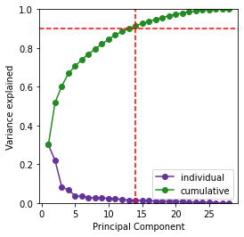

```python
# Prepare dataset for PCA
df_pca = df_df.copy()

# Display Caption
display(HTML('<center style="font-size:12px;font-style:default;">'
             '<b> Figure 5.20 Scree Plot for Explained Variance - Defenders'
             '</b></center>'))

# Define X
X = df_pca
features = df_pca.columns

# Scaling
sscaler = MinMaxScaler()
X_norm = sscaler.fit_transform(X.astype(np.float))
X_norm_df = pd.DataFrame(data = X_norm, columns = features)
X_norm_df

X_new, w, variance_explained = pca(X_norm)

# Scree plot
fig, ax = plt.subplots(figsize=(4,4))
ax.plot(range(1, len(variance_explained)+1), variance_explained, 'o-',
        color='rebeccapurple', label='individual')
ax.plot(range(1, len(variance_explained)+1), variance_explained.cumsum(),
        'o-', color='forestgreen', label='cumulative')
ax.legend()
ax.set_ylim(0, 1)
ax.set_xlabel('Principal Component')
ax.axhline(0.90, ls='--', color='r')
ax.axvline(14, ls='--', color='r')
ax.set_ylabel('Variance explained');
```

**PC1** shows top features mostly on the negative axis. Correlated features are difficult to interpret but we can consider it as an all-around dimension on the negative axis.

For **PC3**, the positive axis is more on the defense-related features and the negative axis is comprised mainly of offense-related features.

**Figure 5.21 Principal Component Biplots - Defenders**

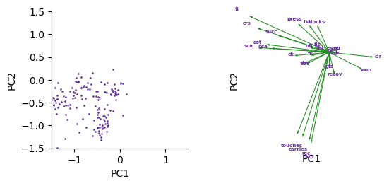

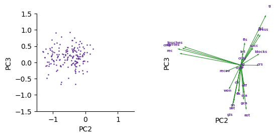

```python
# Define number of PCs
pc_total = 14
X_new = X_norm.dot(w[:, :pc_total])

#Display Caption
display(HTML('<center style="font-size:12px;font-style:default;">'
             '<b> Figure 5.21 Principal Component Biplots - Defenders'
             '</b></center>'))

# Plot 2 biplots for top 3 PCs
plot_pca(X_new, features, w, 3)
```

**Figure 5.22 Top Features for the Top 3 Principal Components - Defenders**

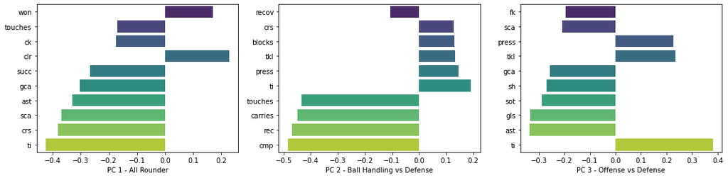

```python
# Display Caption
display(HTML('<center style="font-size:12px;font-style:default;">'
             '<b> Figure 5.22 Top Features for the Top 3 Principal '
             'Components - Defenders'
             '</b></center>'))

# Plot bar graphs of top features per PC
fig, ax = plt.subplots(1, 3, sharey=False, figsize=(18,4))

trunc_w = w[:, :pc_total]

order = np.argsort(np.abs(trunc_w[:, 0]))[-10:]
sns.barplot(y=features[order], x=trunc_w[order, 0],
            palette='viridis', ax=ax[0])

order = np.argsort(np.abs(trunc_w[:, 1]))[-10:]
sns.barplot(y=features[order], x=trunc_w[order, 1],
            palette='viridis', ax=ax[1])

order = np.argsort(np.abs(trunc_w[:, 2]))[-10:]
sns.barplot(y=features[order], x=trunc_w[order, 2],
            palette='viridis', ax=ax[2])

ax[0].set(xlabel='PC 1 - All Rounder', ylabel='')
ax[1].set(xlabel='PC 2 - Ball Handling vs Defense', ylabel='')
ax[2].set(xlabel='PC 3 - Offense vs Defense', ylabel='')

plt.show()
```

### 5.2.3.2 Clustering

Again, Ward's method was the chosen clustering method. In this case, a higher threshold of 4 was used to come up with four different clusters.

**Figure 5.23 Dendogram from Wards Method - Defenders**

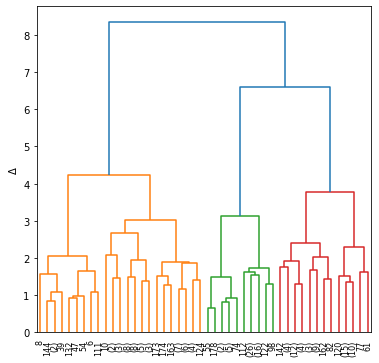

```python
# Scaling
minmax = MinMaxScaler()
X = minmax.fit_transform(df_pca)

stat_columns = df_pca.columns

# PCA
epl_pca = PCA(n_components=14, random_state=1337)
X_new = epl_pca.fit_transform(X)

# Display Caption
display(HTML('<center style="font-size:12px;font-style:default;">'
             '<b> Figure 5.23 Dendogram from Wards Method - Defenders'
             '</b></center>'))

# Wards and Plot
Z = linkage(X, method='ward', optimal_ordering=True)
plot1(Z);
```

**Figure 5.24 Cluster Scatterplot - Defenders**

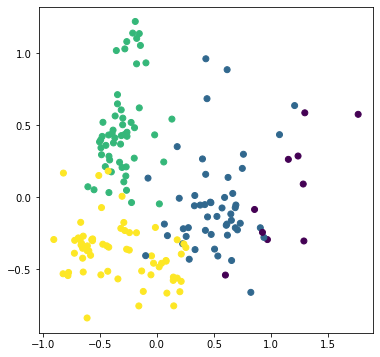

```python
# Display Caption
display(HTML('<center style="font-size:12px;font-style:default;">'
             '<b> Figure 5.24 Cluster Scatterplot - Defenders'
             '</b></center>'))

# Scatter plot on top 2 PCs
y_predict = fcluster(Z, t=4, criterion='distance')
plt.scatter(X_new[:,0], X_new[:,1], c=y_predict);
```

```python
# Combine info df, the processed numerical df and corresponding cluster
df_df2 = pd.concat([df_info, df_df], axis=1).dropna()
df_with_cluster = pd.concat([df_df2.reset_index(),
                             pd.DataFrame(y_predict, columns=['cluster'])],
                            axis=1)
```

**Figure 5.25 Cluster Feature Boxplots - Defenders**

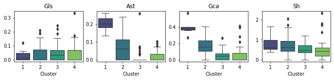

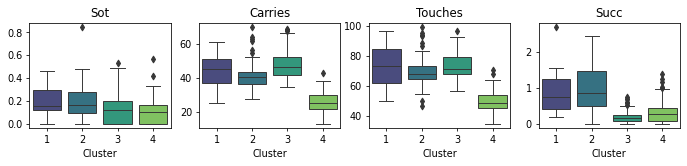

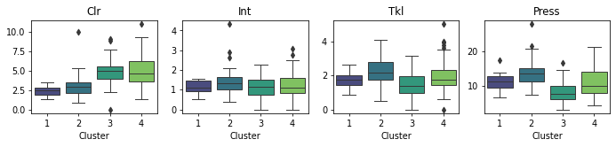

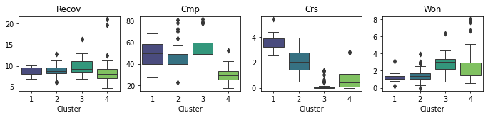

```python
# Display Caption
display(HTML('<center style="font-size:12px;font-style:default;">'
             '<b> Figure 5.25 Cluster Feature Boxplots - Defenders'
             '</b></center>'))

# Feature Boxplots
plot_boxplot_eda(df_with_cluster, 'gls', 'ast', 'gca', 'sh')
plot_boxplot_eda(df_with_cluster, 'sot', 'carries', 'touches', 'succ')
plot_boxplot_eda(df_with_cluster, 'clr', 'int', 'tkl', 'press')
plot_boxplot_eda(df_with_cluster, 'recov','cmp', 'crs', 'won')
```

### Cluster 1 - Wing Backs (Offensive)

Players under this cluster have high assists, goal-creating actions, crosses, and successful dribbles. Just like the wide midfielder cluster, these players mostly play on the flanks. Their primary position is for defense but they mostly help with offense. They make forward runs when in possession of the ball and usually pass the ball through crosses. They are also adept dribblers. Some well-known players under this cluster are Trent Alexander-Arnold, Andrew Robertson, Lucas Digne, Luke Shaw, and Ben Chilwell. See table below for other players comprising this cluster.

```python
# Display Caption
display(HTML('<left style="font-size:12px;font-style:default;">'
             '<b>Table 5.9 Sample Players for Wing Backs</b>'
             '</left>'))

# Display sample players for this cluster
(df_with_cluster[df_with_cluster['cluster'] == 1]
 .sort_values('starts', ascending=False).head(10)[['player', 'squad']])
```

**Table 5.9 Sample Players for Wing Backs**

|  | player | squad |
| --- | --- | --- |
| 133 | Andrew Robertson | Liverpool |
| 47 | Aaron Cresswell | West Ham |
| 8 | Trent Alexander-Arnold | Liverpool |
| 54 | Lucas Digne | Everton |
| 144 | Luke Shaw | Manchester Utd |
| 39 | Ben Chilwell | Chelsea |
| 6 | Marc Albrighton | Leicester City |
| 132 | Matt Ritchie | Newcastle Utd |
| 111 | Arthur Masuaku | West Ham |
| 156 | Alex Telles | Manchester Utd |

### Cluster 2 - Full Backs (Defensive)

```python
# Display Caption
display(HTML('<left style="font-size:12px;font-style:default;">'
             '<b>Table 5.10 Sample Players for Full Backs</b>'
             '</left>'))

# Display sample players for this cluster
(df_with_cluster[df_with_cluster['cluster'] == 2]
 .sort_values('starts', ascending=False).head(10)[['player', 'squad']])
```

**Table 5.10 Sample Players for Full Backs**

|  | player | squad |
| --- | --- | --- |
| 15 | Luke Ayling | Leeds United |
| 48 | Stuart Dallas | Leeds United |
| 153 | Matt Targett | Aston Villa |
| 169 | Aaron Wan-Bissaka | Manchester Utd |
| 143 | Nélson Semedo | Wolves |
| 46 | Vladimír Coufal | West Ham |
| 2 | Ola Aina | Fulham |
| 168 | Kyle Walker-Peters | Southampton |
| 9 | Ezgjan Alioski | Leeds United |
| 27 | Ryan Bertrand | Southampton |

### Cluster 3 - Ball-Playing Defenders

Players under this cluster are focused on their defensive duties but at the same time have a lot of ball-handling responsibilities. They have average defensive features such as clearance and interceptions, but they have a really high score in ball-handling features like completed passes, ball touches, and carries. The players can be compared to the defensive midfielder cluster as well because they sometimes have the same overlapping duties. Famous players in this cluster are Rúben Dias, Victor Lindelöf, Harry Maguire, Ben White and Fabinho. See table below for other sample players in this cluster.

```python
# Display Caption
display(HTML('<left style="font-size:12px;font-style:default;">'
             '<b>Table 5.11 Sample Players for Ball-Playing Defenders</b>'
             '</left>'))

# Display sample players for this cluster
(df_with_cluster[df_with_cluster['cluster'] == 3]
 .sort_values('starts', ascending=False).head(10)[['player', 'squad']])
```

**Table 5.11 Sample Players for Ball-Playing Defenders**

|  | player | squad |
| --- | --- | --- |
| 43 | Conor Coady | Wolves |
| 172 | Ben White | Brighton |
| 23 | Jan Bednarek | Southampton |
| 106 | Harry Maguire | Manchester Utd |
| 1 | Tosin Adarabioyo | Fulham |
| 60 | Lewis Dunk | Brighton |
| 87 | Michael Keane | Everton |
| 52 | Rúben Dias | Manchester City |
| 13 | Joachim Andersen | Fulham |
| 165 | Jannik Vestergaard | Southampton |

### Cluster 4 - Ball-Winning Defenders

This cluster includes players that can be described as the main defenders. They have the lowest scores in offensive and ball handling features, and the only categories they excel in are the defensive features like tackles, clearances, and interceptions. These players are focused solely on the task of defending the goal. Noteworthy players from this cluster are Tyrone Mings, James Tarkowski, Ben Godfrey, Ben Mee and Cheikhou Kouyaté. Refer to the table below for other sample players belonging to this cluster.

```python
# Display Caption
display(HTML('<left style="font-size:12px;font-style:default;">'
             '<b>Table 5.12 Sample Players for Ball-Winning Defenders</b>'
             '</left>'))

# Display sample players for this cluster
(df_with_cluster[df_with_cluster['cluster'] == 4]
 .sort_values('starts', ascending=False).head(10)[['player', 'squad']])
```

**Table 5.12 Sample Players for Ball-Winning Defenders**

|  | player | squad |
| --- | --- | --- |
| 154 | James Tarkowski | Burnley |
| 116 | Tyrone Mings | Aston Villa |
| 92 | Ezri Konsa | Aston Villa |
| 93 | Cheikhou Kouyaté | Crystal Palace |
| 104 | Matthew Lowton | Burnley |
| 70 | Darnell Furlong | West Brom |
| 19 | George Baldock | Sheffield Utd |
| 4 | Semi Ajayi | West Brom |
| 22 | Chris Basham | Sheffield Utd |
| 62 | John Egan | Sheffield Utd |

### Summary of the Formed Clusters

**Table 5.13 Table of Clusters per Position**

| Position | Cluster 1 | Cluster 2 | Cluster 3 | Cluster 4 |
| --- | --- | --- | --- | --- |
| Forwards | All-Around Forward | Natural Forward | Aerial Forward | Defensive-Minded Forward |
| Midfielders | Utility Midfielder | Wide Midfielder | Holding Midfielder | Attacking Midfielder |
| Defenders | Wing Back | Full Back | Ball-Playing Defender | Ball-Winning Defender |

## 6. Conclusion and Recommendation

Our group was able to produce a total of twelve unique clusters based on three football positions (table 5.13). For Forwards, we have All-Around Forwards, Natural forwards, Aerial Forwards, and Defensive-Minded Forwards. All-Around forwards are more focused on playmaking while natural forwards are out in the field to score. Aerial forwards are also agressive in scoring but are more equipped with aerial abilities and physical types of play. Defensive-minded forwards, on the other hand, put an equal emphasis on defense and offense despite being forwards. For the Midfielder position, there are Utility Midfielders, Wide Midfielders, Holding Midfielders, and Attacking Midfielders. Utility Midfielders execute a lot of presses as well as pass interceptions and do a lot of both playmaking and defending. Wide midfielders usually play on the flanks and typically do a lot of crosses and dribbles. Holding midfielders are the most defensive-minded in the cluster, focusing on defensive actions like interceptions, ball tackles, and recoveries. Attacking midfielders, in contrast, are focused on attacking and contributing goals to the team. Finally, for Defenders, we have the Wing Backs, Full Backs, Ball-Playing Defenders, and Ball-Winning Defenders. Wingbacks, just like wide midfielders play on the flanks and are focused on attacking and scoring; they are very good at passes, crosses, and dribbles. Fullbacks, although on the defensive side, also attack and score. Ball-playing defenders are focused on defense and have many opportunites to control the ball. Ball-winning defenders are the main defenders; they excel in defensive actions such as tackles clearances and interceptions with a focus on defending their own goalpost.

To take full advantage of our formed clusters on player positions, our identified use cases are for sports teams, coaches, managers, game analyts, and scouts. Football teams, coaches, and managers are able to harness the power of these clusters to identify distributions of these types of players within their teams. With this, they can allocate resources wisely by replacing players with similar attributes once contracts expire, as well as fill in the open slots for specific players in their current roster. Scouts can use these clusters to pinpoint players from other teams or leagues for possible recruitment and player acquisitions. Furthermore, competitor's abilities can be identified from these clusters. Clubs are able to maximize their chances of winning by studying their opponent's tendencies as well as their strengths and weaknesses.

Our team recommends future proponents or researchers who have interest in this topic to delve further into football position analysis. They can start by expanding their dataset and utilize other pertinent statistics found on our source websites or other sources of information. They can take a step further and perform clustering techniques on players across different seasons of the English Premier League. Should they choose to use Ward's method for clustering, soft clusters found deeper into the dendogram can be explored to create more personalized profiles that would best fit their use case. The same methods, processes, and analysis can also be performed on additional top football leagues and football competitions such as the Spanish La Liga, the Italian Serie A, the FIFA World Cup, and the Olympics. Finally, machine learning algorithms can be utlized to predict clusters or specific player positions based on several game and player statistics.

## 7. References

We would like to acknowledge our references for this study:

- Premier League Wikipedia page (n.d.), https://en.wikipedia.org/wiki/Premier_League
- Fantasy Sports Wikipedia page (n.d.), https://en.wikipedia.org/wiki/Fantasy_sport
- FBREF website (n.d.), https://fbref.com/en/about/
- Premier League website (n.d.), https://www.premierleague.com/about
- Association Football Wikipedia page (n.d.), https://en.wikipedia.org/wiki/Assist_(association_football)
- Sports Pundit website (n.d), https://www.sportspundit.com/soccer/terms/224-clean-sheet
- Forward (association football) Wikipedia page (n.d.), https://en.wikipedia.org/wiki/Forward_(association_football)
- Barca Innovation hub (n.d), https://barcainnovationhub.com/the-influence-of-age-on-footballers-performance/
- List of Premier League Clubs (n.d.), https://en.wikipedia.org/wiki/List_of_Premier_League_clubs
- Association football positions (n.d.) https://en.wikipedia.org/wiki/Association_football_positions
- Clearance (n.d) https://www.sportspundit.com/soccer/terms/3006-clearance
- Interception (n.d) https://www.sportspundit.com/football/terms/2408-interception
- Opta Event Definitions (n.d.) https://www.statsperform.com/opta-event-definitions/
- Passing (Association Football) (n.d.) https://en.wikipedia.org/wiki/Passing_(association_football)
- Introduction to Soccer Tackling (n.d.) https://coachingamericansoccer.com/introductions-to-skills/introduction-to-soccer-tackling-the-front-block-tackle/